# 0042 STDM Report

2023-03-09

# Import and Preprocessing Data

## Read Dataset

Read the original data set as a dataframe, name the corresponding columns, and filter out the detection stations located on Mainlane.

```r
compressed_file <- "PeMS/d08_text_station_hour_2023_01.txt.gz"
lines <- readr::read_lines(gzfile(compressed_file))

lines_text <- paste(lines, collapse = "\n")

dataframe <- read_csv(lines_text, col_names = c("TimeStamp",
                                                "Station",
                                                "District",
                                                "Route",
                                                "Direction",
                                                "LaneType",
                                                "StationLength",
                                                "Samples",
                                                "Observed",
                                                "Flow",
                                                "AvgOccupancy",
                                                "AvgSpeed",
                                                "Delay (V_t=35)",
                                                "Delay (V_t=40)",
                                                "Delay (V_t=45)",
                                                "Delay (V_t=50)",
                                                "Delay (V_t=55)",
                                                "Delay (V_t=60)",
                                                "Lane N Flow",
                                                "Lane N Avg Occ",
                                                "Lane N Avg Speed"
))
dataframe <- dataframe[dataframe$LaneType == "ML",]
```

Import a metadata dataset containing latitude and longitude:

```r
metadata <- read_delim("PeMS/d08_text_meta_2023_01_01.txt", delim = "\t", na = "")
metadata_cor <- metadata[, c("ID", "Longitude", "Latitude")]
```

Merge the two datasets and filter out the required columns

```r
result <- merge(dataframe, metadata_cor, by.x = "Station", by.y = "ID", all.x = TRUE)

# filter data with needed columns
data  <- result[, c("Station","TimeStamp","Flow","Route","Direction","LaneType","Longitude","Latitude")]
```

Check for missing values:

```r
missing_values <- is.na(data)
missing_values_count <- colSums(missing_values)
missing_values_count
```

```
##   Station TimeStamp      Flow     Route Direction  LaneType Longitude  Latitude
##         0         0         0         0         0         0         0         0
```

The results show that none of the required columns have missing values. The next step of data processing can be performed.

## Process the data for building an ARIMA model

Find out the traffic flow data corresponding to the target station (ID: 817198).

```r
target_station_flow <- data[data$Station == 817198,1:3]
target_station_flow <- target_station_flow[order(target_station_flow$TimeStamp), ]

# head(target_station_flow)
```

## Process the data for building the ST-ARIMA model:

Next, find the detection stations and their traffic flow data within a radius of 5 kilometers from the station. First calculate the distance and filter out the station IDs within the range:

```r
station_target <- metadata_cor[metadata_cor$ID == 817198,]
head(station_target)
```

```
## # A tibble: 1 × 3
##       ID Longitude Latitude
##    <dbl>     <dbl>    <dbl>
## 1 817198     -118.     34.1
```

```r
# Calculate the distance between station_target and other stations
distance_to_target <- t(distm(cbind(station_target$Longitude, station_target$Latitude),
                            cbind(metadata_cor$Longitude, metadata_cor$Latitude),
                            fun = distVincentySphere))
# add the distance to the original dataset
station_with_distance <- cbind(metadata_cor, distance = distance_to_target)

# Filter out all points within a radius of 5 kilometers from station_target (including station_target itself)
filtered_stations <- station_with_distance[station_with_distance$distance<=5000,]

# head(filtered_stations)
```

The filtered stations can be displayed on the map

```r
map <- leaflet() %>%
  addProviderTiles(providers$OpenStreetMap) %>%
  setView(lng = mean(filtered_stations$Longitude),
          lat = mean(filtered_stations$Latitude),
          zoom = 10)

map <- map %>%
  addCircleMarkers(data = station_target,
                   lng = ~Longitude,
                   lat = ~Latitude,
                   color = "Green",
                   radius = 3) %>%
  addCircleMarkers(data = filtered_stations,
                   lng = ~Longitude,
                   lat = ~Latitude,
                   color = "red",
                   radius = 5) %>%
  addProviderTiles("CartoDB.Positron")

map
```

[interactive chart not shown]

Next, create a data frame, including the traffic flow data of these detection stations that have been filtered out:

```r
merged_df <- merge(data,filtered_stations,by.x = "Station", by.y = "ID")

filtered_df <- merged_df[, c("Station", "TimeStamp", "Flow")]
filtered_df <- filtered_df[order(filtered_df$TimeStamp), ]

# head(filtered_df)
```

Convert this dataset to wide format, where each row is a detection station:

```r
Station_flow <- dcast(filtered_df, Station ~ TimeStamp, value.var = "Flow")

# head(Station_flow)
```

Exclude stations with no data:

```r
filtered_stations <- filtered_stations[filtered_stations$ID %in% Station_flow$Station, ]
```

# Data Exploratory Analysis

## Perform exploratory data analysis on univariate time series

First convert the dataset into a ts object:

```r
target_station_flow$TimeStamp <- as.POSIXct(
  target_station_flow$TimeStamp,
  format = "%Y-%m-%d %H:%M:%S")

target_station_flow_ts <- ts(target_station_flow$Flow, frequency = 24)
```

Visualize data:

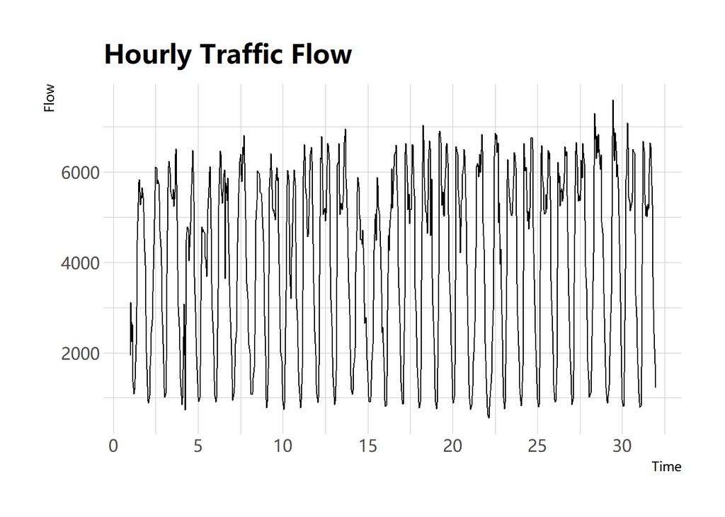

```r
autoplot(target_station_flow_ts) +
  ggtitle("Hourly Traffic Flow") +
  xlab("Time") +
  ylab("Flow")
```

Before modeling, we need to test the time stationarity of the data Perform an ADF test on the data:

```r
adf_test <- adf.test(target_station_flow_ts, alternative = "stationary")
print(adf_test)
```

```
##
##  Augmented Dickey-Fuller Test
##
## data:  target_station_flow_ts
## Dickey-Fuller = -12.95, Lag order = 9, p-value = 0.01
## alternative hypothesis: stationary
```

Perform time series decomposition：

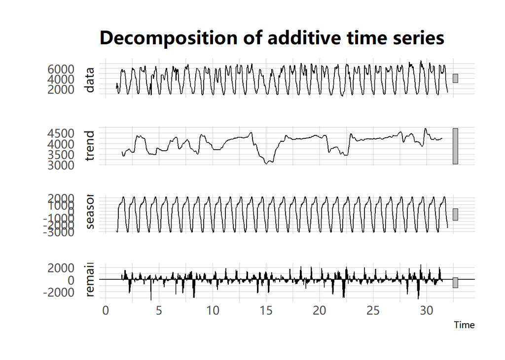

```r
data_ts_decomposed <- stats::decompose(target_station_flow_ts)

autoplot(data_ts_decomposed)
```

## Perform exploratory data analysis on spatio-temporal series

First, we can focus on the non-spatial-temporal features. Let’s look at the simple statistical characteristics:

```r
Station_flow_mtx<-data.matrix(Station_flow[,2:ncol(Station_flow)])
mu = mean(Station_flow_mtx)
sdev = sd(Station_flow_mtx)
print(mu)
```

```
## [1] 3426.657
```

```r
print(sdev)
```

```
## [1] 1718.332
```

draw histogram

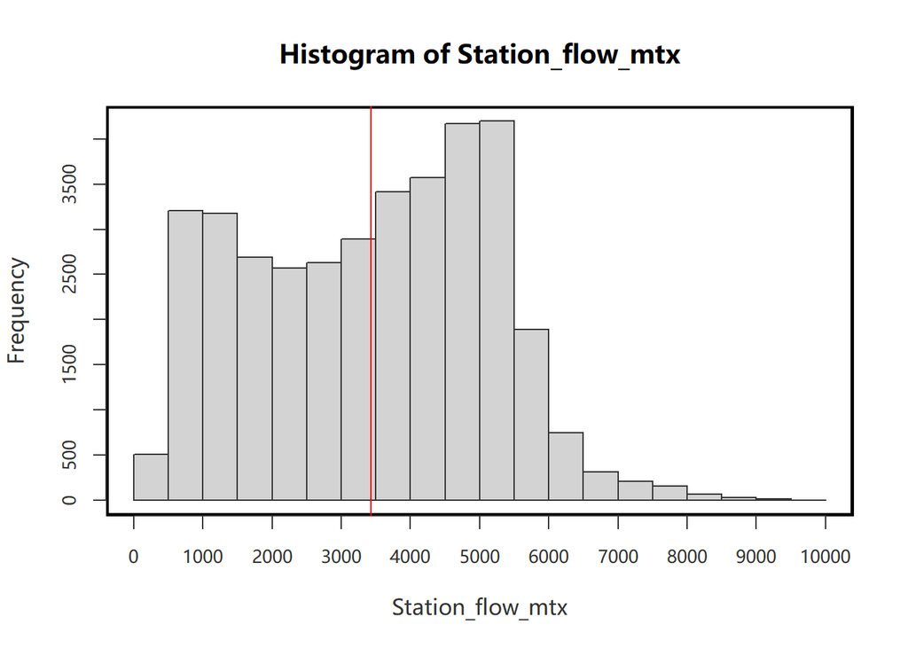

```r
hist(Station_flow_mtx)
abline(v=mu, col="red")
```

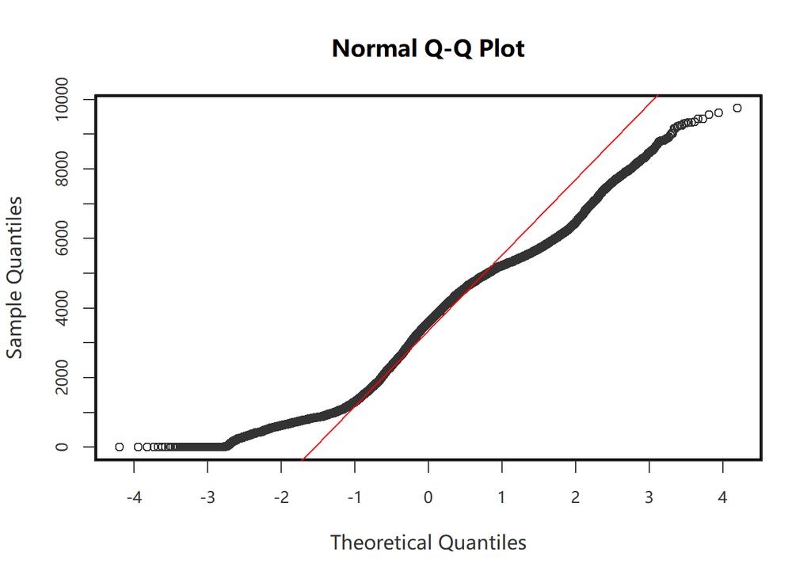

```r
qqnorm(Station_flow_mtx)
qqline(Station_flow_mtx, col="red")
```

Next, we can look at the time distribution of traffic flow at each station. Due to the large amount of data, we only select the data of the first week for exploration:

```r
spatial_data_EDA <- Station_flow[ ,1:((24*7)+2)]
# head(spatial_data_EDA)
```

View the traffic flow changes at each station with a heat map

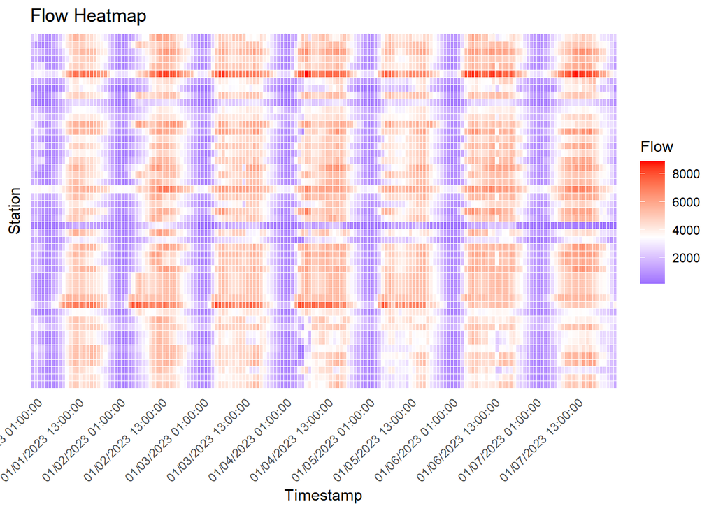

```r
heatmap_data_long <- melt(spatial_data_EDA, id.vars = "Station", variable.name = "TimeStamp", value.name = "Flow")
# Extract the 0:00 and 12 o'clock of each day as x.axis
timestamp_ticks <- seq(3, ncol(spatial_data_EDA) - 1, by = 12)

# plot heatmap
ggplot(heatmap_data_long, aes(x = TimeStamp, y = factor(Station), fill = Flow)) +
  geom_tile(color = "white") +
  scale_fill_gradient2(low = "blue", mid = "white", high = "red", midpoint = median(heatmap_data_long$Flow)) +
  scale_x_discrete(breaks = colnames(spatial_data_EDA)[timestamp_ticks]) +
  scale_y_discrete(labels = NULL) +
  theme_minimal() +
  theme(axis.text.x = element_text(angle = 45, hjust = 1)) +
  labs(x = "Timestamp", y = "Station", title = "Flow Heatmap")
```

# Model building

## ARIMA Model

Plot ACF and PACF:

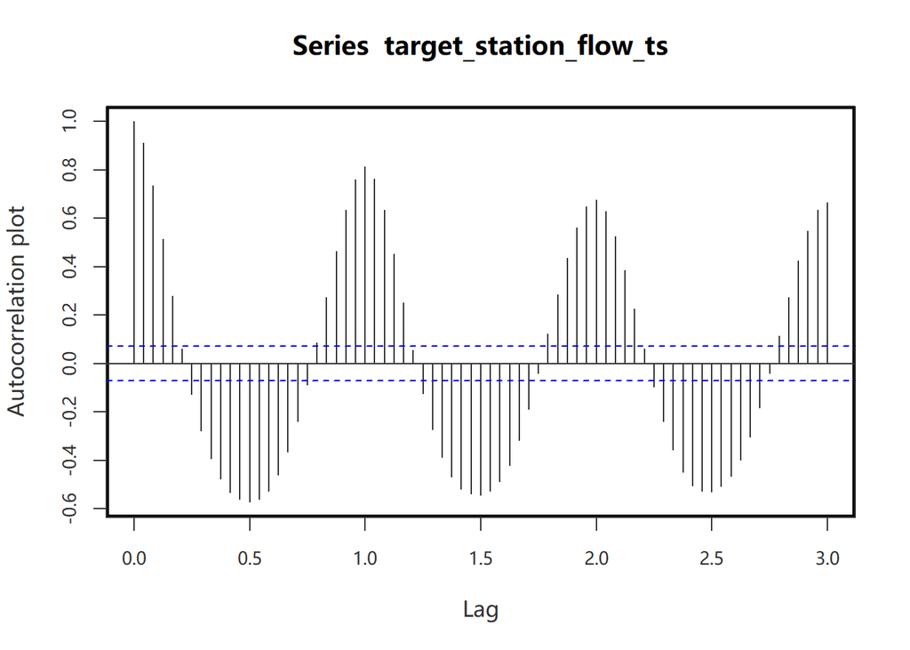

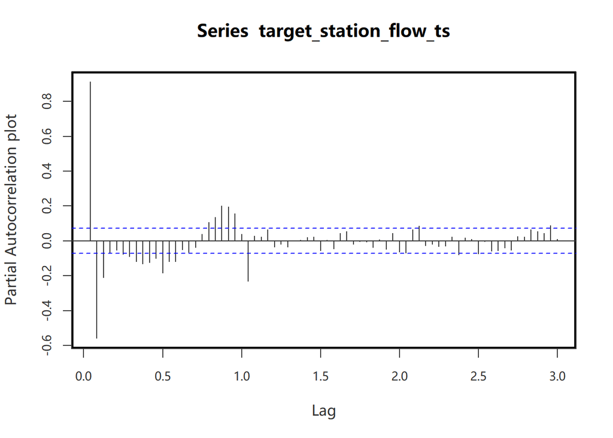

It can be seen that the seasonal trend is obvious. Next we take the first order seasonal difference and look at the acf plot again:

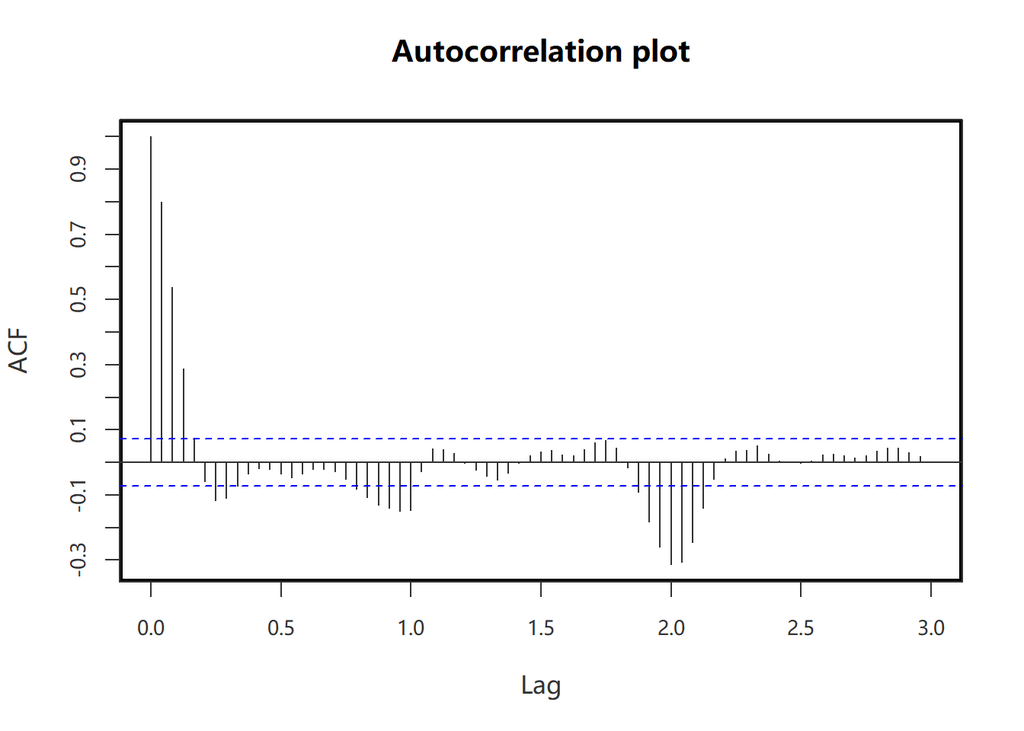

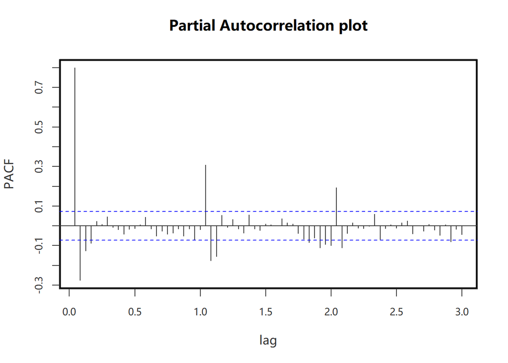

The model parameters can be read as arima(4,0,0)(2,1,2). Divide the training set and test set, and test the prediction effect of the model:

```r
# Normalize the raw time series data
normalized_target_station_flow_ts <- (target_station_flow_ts - min(target_station_flow_ts)) / (max(target_station_flow_ts) - min(target_station_flow_ts))

# Use the data before 00:00 on January 26, 2023 as the training set, and other data as the test set
single_train_data_normalized <- ts(normalized_target_station_flow_ts[1:(24*25)], frequency = 24)
single_test_data_normalized <- ts(normalized_target_station_flow_ts[((24*25)+1):744], frequency = 24)

# Fit the ARIMA model to the normalized training data
fit.ar <- arima(single_train_data_normalized, order=c(4, 0, 0), seasonal=list(order=c(2, 1, 2), period=24))
summary(fit.ar)
```

```
##
## Call:
## arima(x = single_train_data_normalized, order = c(4, 0, 0), seasonal = list(order = c(2,
##     1, 2), period = 24))
##
## Coefficients:
```

```
##          ar1      ar2      ar3      ar4     sar1    sar2     sma1     sma2
##       0.9921  -0.1052  -0.1329  -0.0582  -0.5776  0.0989  -0.1556  -0.6793
## s.e.  0.0058      NaN      NaN      NaN   0.0231  0.0271   0.1682   0.0793
##
## sigma^2 estimated as 0.005446:  log likelihood = 666.01,  aic = -1314.02
##
## Training set error measures:
##                       ME       RMSE        MAE  MPE MAPE      MASE
## Training set 0.003818268 0.07230837 0.04950089 -Inf  Inf 0.5755474
##                       ACF1
## Training set -0.0006629686
```

Use the model to make predictions:

```r
n_periods <- 24*6 # Number of forecast periods
arima_forecast <- forecast(fit.ar, h = n_periods)
```

Draw a graph to see the fitting effect:：

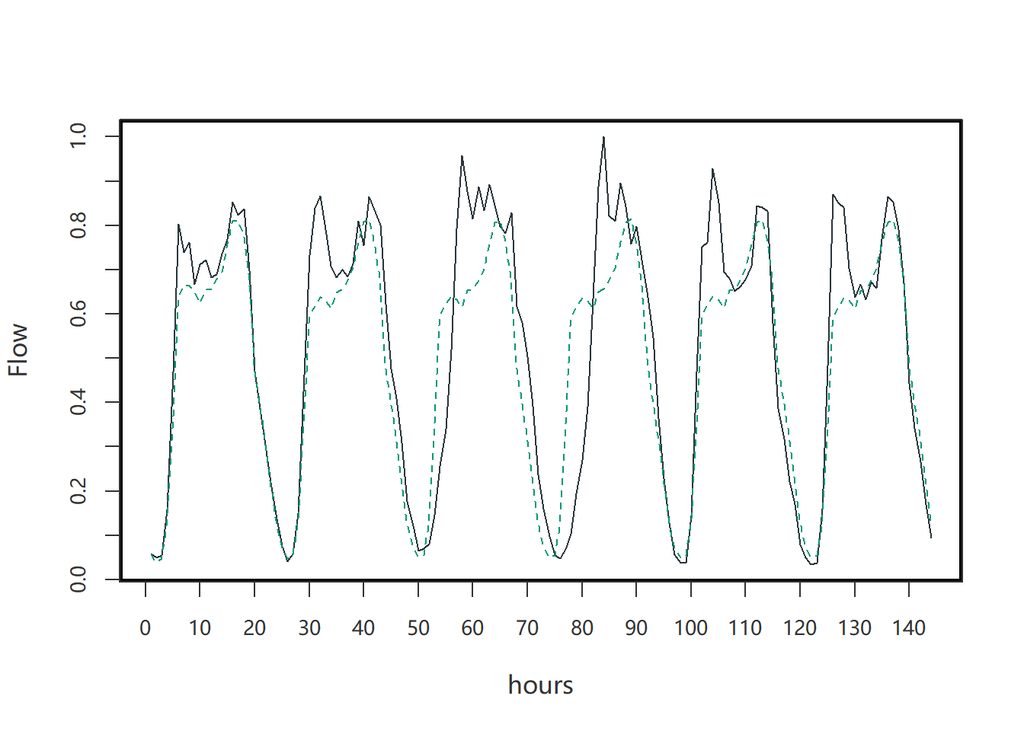

[output not shown]

```r
predict_data <- as.data.frame(arima_forecast$mean)
actual_data <- as.data.frame(single_test_data_normalized)

matplot(1:144,cbind(actual_data, predict_data),type="l",xlab = "hours",ylab = "Flow")
```

```r
# Get the start value and end value of the forecast data
forecast_start <- start(arima_forecast$mean)
forecast_end <- end(arima_forecast$mean)

# Set the start and end values for the actual data
single_test_data_ts <- ts(single_test_data_normalized, start=forecast_start, end=forecast_end)

# Compute accuracy metrics using time series objects
accuracy_metrics <- accuracy(arima_forecast$mean, single_test_data_ts)
accuracy_metrics
```

```
##                  ME       RMSE        MAE      MPE     MAPE      ACF1 Theil's U
## Test set 0.05219198 0.08100336 0.05219198 15.87936 15.87936 0.4263178 0.3133205
```

Next, try modeling with auto.arima for comparison. Modeling with auto.arima:

```r
auto_ar_model <- auto.arima(single_train_data_normalized)
summary(auto_ar_model)
```

```
## Series: single_train_data_normalized
## ARIMA(3,0,0)(2,1,0)[24]
##
## Coefficients:
##          ar1      ar2      ar3     sar1     sar2
##       1.0052  -0.0929  -0.1970  -0.4564  -0.2822
## s.e.  0.0417   0.0610   0.0414   0.0406   0.0391
##
## sigma^2 = 0.006893:  log likelihood = 614.31
## AIC=-1216.62   AICc=-1216.48   BIC=-1190.49
##
## Training set error measures:
##                       ME       RMSE        MAE  MPE MAPE      MASE        ACF1
## Training set 0.001714886 0.08099487 0.05377452 -Inf  Inf 0.5478585 -0.01303764
```

Use the model to make predictions:

```r
n_periods <- 24*6
auto_arima_forecast <- forecast(auto_ar_model, h = n_periods)
```

Draw a graph to see the fitting effect:

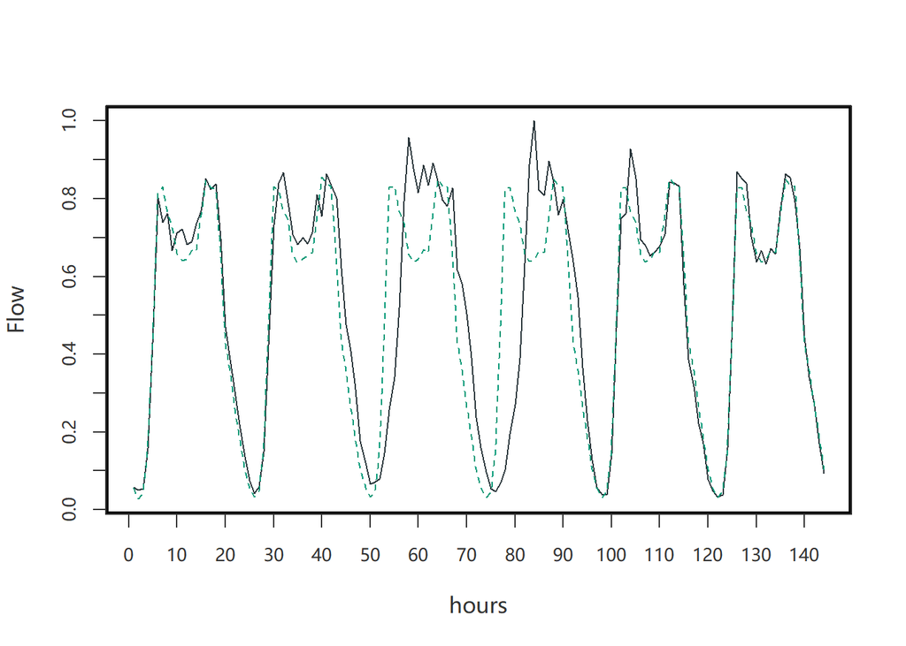

```r
predict_data <- as.data.frame(auto_arima_forecast$mean)
actual_data <- as.data.frame(single_test_data_normalized)

matplot(1:144,cbind(actual_data, predict_data),type="l",xlab = "hours",ylab = "Flow")
```

Calculate the statistical indicators of the forecast results

```r
forecast_start <- start(auto_arima_forecast$mean)
forecast_end <- end(auto_arima_forecast$mean)

single_test_data_ts <- ts(single_test_data_normalized, start=forecast_start, end=forecast_end)

accuracy_metrics <- accuracy(auto_arima_forecast$mean, single_test_data_ts)
accuracy_metrics
```

[output not shown]

## ST-ARIMA Model

The biggest difference between the ARIMA model and the ST-ARIMA model is the consideration of the spatial weight matrix. Therefore, it is very important to calculate a reasonable spatial weight matrix. Since the prediction object is traffic flow data, the Euclidean distance between two detection stations cannot be simply calculated. An innovative point of this study is that the road network data is introduced, and the shortest path distance between two detection stations is calculated using Dijkstra’s shortest path algorithm to generate a distance matrix. The inverse distance weight matrix is then used as the spatial weight matrix. First, import the road network data. The road network data includes road network nodes and road network edges, which are processed in ArcGIS in advance, and only the road network nodes on the mainlane are retained. We can view the road network data on the map:

```r
# import road network data
road_nodes <- read_delim("PeMS/nodes.txt", delim = "\t",na = "",col_names = c("nodeID","longitude","latitude"))
road_edges <- read_delim("PeMS/edges.txt", delim = "\t",na = "",col_names = c("edgeID","start_node","end_node","distance"))
```

```r
# Add road network nodes to the map:
road_nodes$longitude <- as.numeric(road_nodes$longitude)
road_nodes$latitude <- as.numeric(road_nodes$latitude)

map_road <- leaflet() %>%
  addProviderTiles(providers$OpenStreetMap) %>%
  setView(lng = mean(road_nodes$longitude),
          lat = mean(road_nodes$latitude),
          zoom = 10)

map_road <- map_road %>%
  addCircleMarkers(data = road_nodes,
                   lng = ~longitude,
                   lat = ~latitude,
                   color = "Green",
                   radius = 3) %>%
  addProviderTiles("CartoDB.Positron")

map_road
```

[interactive chart not shown]

To calculate the path distance based on the road network, you need to find the nearest node to each detection station, and add the ID of the node to the station dataset. The calculation process is as follows:

```r
# First calculate the road network node closest to the station:
filtered_stations_sf <- st_as_sf(filtered_stations, coords = c("Longitude", "Latitude"), crs = 4326)
road_nodes_sf <- st_as_sf(road_nodes, coords = c("longitude", "latitude"), crs = 4326)

# Calculate the distance matrix between each node and the nearest road network node
distance_matrix <- st_distance(filtered_stations_sf, road_nodes_sf)

# Find the nearest road network node index for each site
nearest_node_indices <- apply(distance_matrix, 1, which.min)

# Use these indexes to add the nearest road network node ID to the station
filtered_stations$nearest_node <- road_nodes$nodeID[nearest_node_indices]
```

Next, we can use the nearest_node of each site to calculate the shortest path distance. First, generate a graph object, put nodes and edges into the graph object, and assign weights to each edge according to its length.

```r
# create graph object
road_edges <- road_edges[, c("start_node", "end_node", "distance", "edgeID")]
graph <- graph_from_data_frame(d = road_edges, vertices = road_nodes, directed = FALSE)

# Assign weights to edges
E(graph)$weight <- road_edges$distance

# Assign IDs to vertices in the graph
V(graph)$name <- V(graph)

# Add a vertex ID (the index of the nodes in the graph) to each station in the stations data frame
filtered_stations$vertex_id <- match(filtered_stations$nearest_node, V(graph)$name)
```

Next we can calculate the shortest distance between nearest_nodes using the shortest path algorithm:

```r
# Calculate the shortest path distance matrix between each site using Dijkstra's algorithm
shortest_path_matrix <- distances(graph, v = unique(filtered_stations$vertex_id), to = unique(filtered_stations$vertex_id), weights = E(graph)$weight)

dim(shortest_path_matrix)
```

```
## [1] 19 19
```

Compute the inverse distance weight matrix and row normalize it as a weight matrix:

```r
weights <- 1/station_distance_matrix
weights[!is.finite(weights)] <- 0

# row normalization
row_sums <- apply(weights, 1, sum)

weights_norm <- t(t(weights) / row_sums)

# Save it as a csv file for later reading
write.csv(weights_norm, "weights.csv")

# Normalize the weight matrix
wl <- mat2listw(weights_norm, style = "W")
```

At this point, the calculation of the spatial weight matrix is completed.

Before building ST-ARIMA Model, we need to ensure that the data is spatially correlated.

We use Moran’s I to calculate the spatial correlation, where the traffic flow value of each station is represented by the mean value:

```r
# Calculate the monthly average traffic flow of each station
Station_flow$average_flow <- rowMeans(Station_flow_mtx)
Station_flow$average_flow
```

```
##  [1] 3072.374 2818.587 2451.668 3321.731 3550.142 3048.565 2761.073 2923.712
##  [9] 3877.382 3364.806 2650.242 4397.542 4070.298 3568.867 3568.867 3568.867
## [17] 3982.071 3626.680 3876.575 3902.445 2125.011 3310.247 1147.737 3511.353
## [25] 3776.102 3126.765 3916.138 4735.868 3380.395 3568.867 3646.804 3542.227
## [33] 3267.867 3583.565 3287.712 4012.871 3824.755 3369.681 3009.469 1833.852
## [41] 3568.867 2274.444 2903.796 5845.134 3578.116 3518.675 4236.962 4058.284
## [49] 3542.113
```

```r
Station_AvgFlow <- data.frame(
  station = Station_flow$Station,
  average_flow = Station_flow$average_flow
)

# head(Station_AvgFlow)
```

The spatial autocorrelation can then be calculated:

```r
average_flow <- merge(Station_AvgFlow, metadata_cor, by.x = "station", by.y = "ID", all.x = TRUE )
coordinates(average_flow) <- ~Longitude + Latitude

# Compute the Moran Index
flow_variable <- as.numeric(average_flow$average_flow)
moran_test <- moran.test(flow_variable, wl)

print(moran_test)
```

```
##
##  Moran I test under randomisation
##
## data:  flow_variable
## weights: wl
##
## Moran I statistic standard deviate = 4.4374, p-value = 4.552e-06
## alternative hypothesis: greater
## sample estimates:
## Moran I statistic       Expectation          Variance
##      0.0884386632     -0.0208333333      0.0006063959
```

The results show significant autocorrelation.

Now, the ST-ARIMA model can be established:

```r
data_mtx <- as.matrix(t(Station_flow_mtx))

# Custom normalization function
normalize <- function(x) {
  return ((x - min(x)) / (max(x) - min(x)))
}

# Normalize the entire data matrix
data_mtx <- apply(data_mtx, 2, normalize)

train_data <- ts(data_mtx[1:(24*25),],frequency = 24)
test_data <- ts(data_mtx[(24*25+1):(24*31),],frequency = 24)
```

Draw ST-ACF and ST-PACF diagrams

```
## [1] 1
## [1] 1
## [1] 1
## [1] 1
```

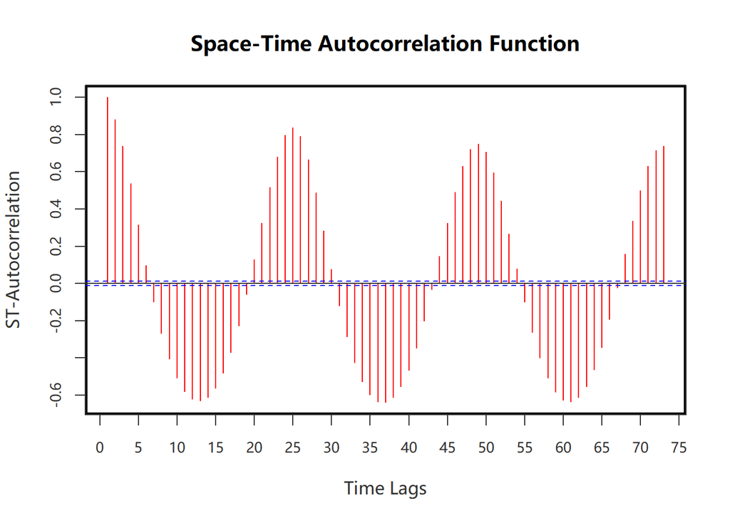

```
## [1] 1
```

```
## $stacf
##              [,1]
##  [1,]  1.00000000
##  [2,]  0.88067172
##  [3,]  0.73776431
##  [4,]  0.53840294
##  [5,]  0.31629367
##  [6,]  0.09758327
##  [7,] -0.09913772
##  [8,] -0.26791302
##  [9,] -0.40510405
## [10,] -0.50866685
## [11,] -0.57995178
## [12,] -0.62053435
## [13,] -0.63132277
```

[output cut: 66 more lines]

```
## [1] 1
## [1] 1
## [1] 1
```

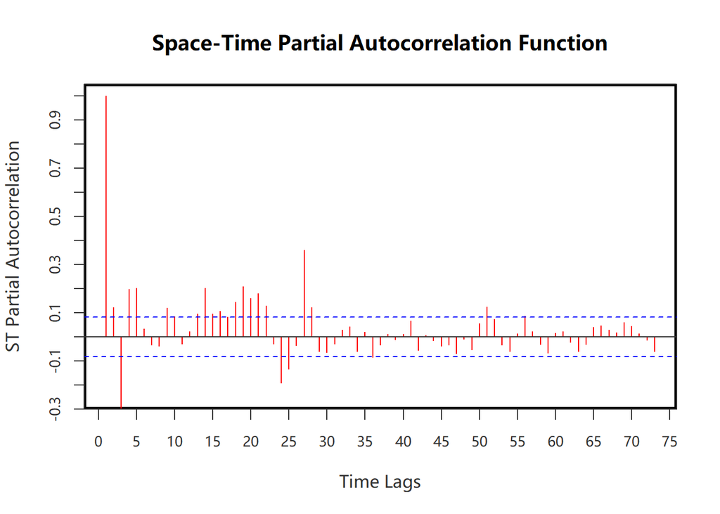

```
## $stpacf
##               [,1]
##  [1,]  1.000000000
##  [2,]  0.122183811
##  [3,] -0.626957145
##  [4,]  0.197241841
##  [5,]  0.201869212
##  [6,]  0.033569060
##  [7,] -0.033622303
##  [8,] -0.037935945
##  [9,]  0.119673349
## [10,]  0.084046507
## [11,] -0.028887975
## [12,]  0.021686554
## [13,]  0.094240024
```

[output cut: 66 more lines]

The ST-ACF graph shows obvious periodicity, requiring first-order seasonal difference:

```
## [1] 1
## [1] 1
## [1] 1
## [1] 1
```

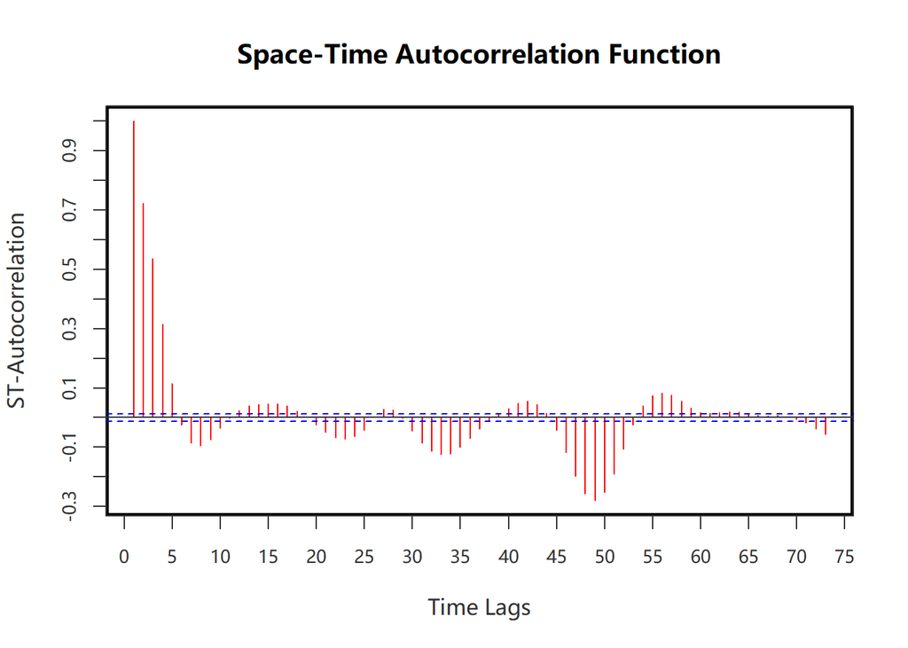

```
## [1] 1
```

```
## $stacf
##                [,1]
##  [1,]  1.0000000000
##  [2,]  0.7224097891
##  [3,]  0.5372589460
##  [4,]  0.3156192930
##  [5,]  0.1153419970
##  [6,] -0.0231602839
##  [7,] -0.0862815692
##  [8,] -0.0955709725
##  [9,] -0.0740086095
## [10,] -0.0353626915
## [11,] -0.0007151036
## [12,]  0.0249789689
## [13,]  0.0397060801
```

[output cut: 66 more lines]

```
## [1] 1
## [1] 1
## [1] 1
```

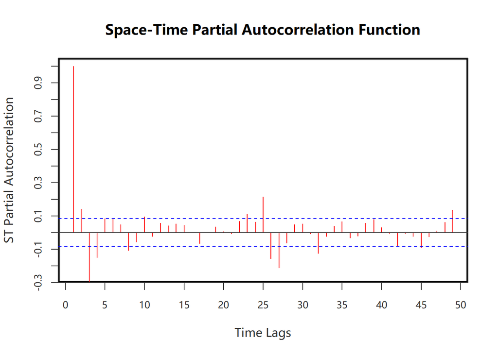

```
## $stpacf
##               [,1]
##  [1,]  1.000000000
##  [2,]  0.142696501
##  [3,] -0.604058002
##  [4,] -0.148842359
##  [5,]  0.085121250
##  [6,]  0.084261254
##  [7,]  0.049252448
##  [8,] -0.106474212
##  [9,] -0.055783723
## [10,]  0.096161815
## [11,] -0.023175458
## [12,]  0.056481079
## [13,]  0.042635326
```

[output cut: 42 more lines]

The relevant parameters that can be read from the ST-ACF and ST-PACF diagrams are p=2, d=24, q=3. Use these parameters to fit ST-ARIMA model：

```
## [1] 1
## [1] 1
## [1] 1
## [1] 1
```

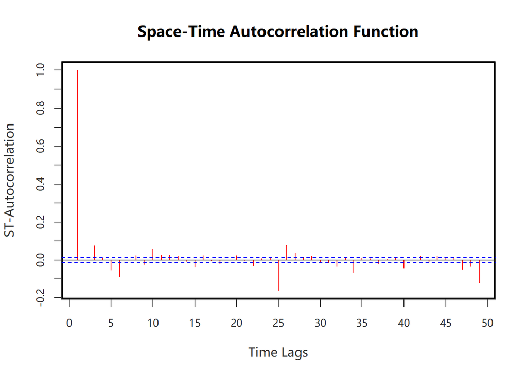

```
## [1] 1
```

```
## $stacf
##                [,1]
##  [1,]  1.0000000000
##  [2,] -0.0013757514
##  [3,]  0.0750311384
##  [4,]  0.0111514049
##  [5,] -0.0532610571
##  [6,] -0.0867634113
##  [7,]  0.0010504259
##  [8,]  0.0233921146
##  [9,] -0.0227064047
## [10,]  0.0566538550
## [11,]  0.0254377530
## [12,]  0.0268863416
## [13,]  0.0186905676
```

[output cut: 42 more lines]

```r
# Save the row index of the target spatial unit
index <- which(Station_flow$Station == 817198)

W_fit<-list(w1=weights_norm)
fit.star <- starima_fit(data_mtx[1:600,],W_fit,p=2,d=24,q=3)
stacf(fit.star$RES, weights_norm,48)
```

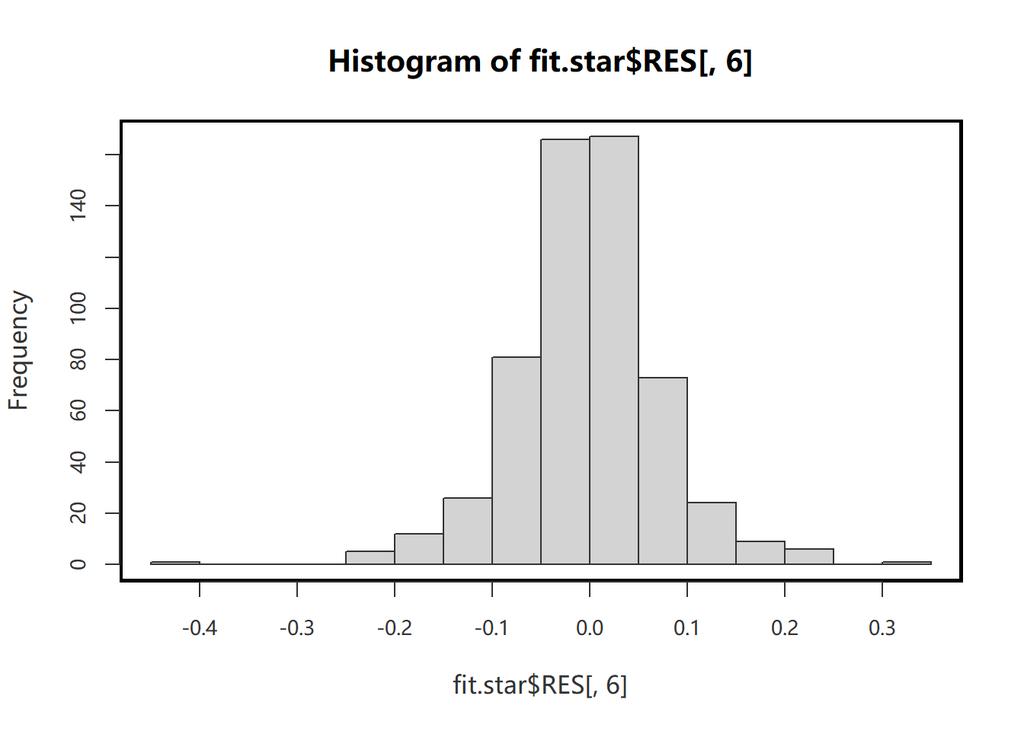

```r
hist(fit.star$RES[,6])
```

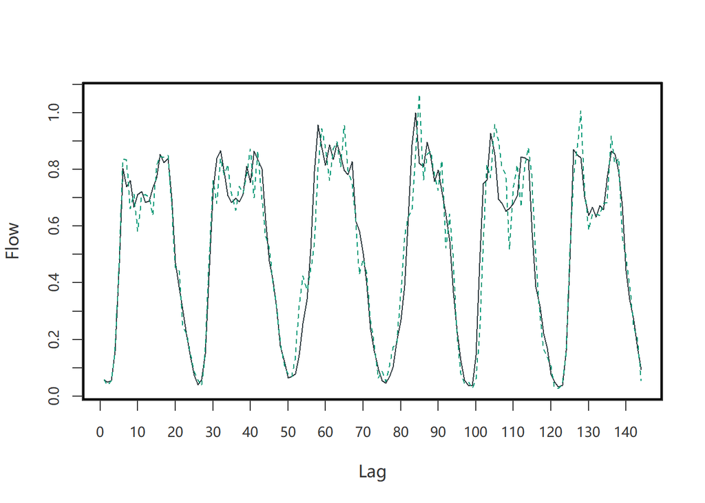

```r
pre.star <- starima_pre(data_mtx[(600-24-5+1):744, ],model=fit.star)
matplot(1:144,cbind(data_mtx[601:744,index],pre.star$PRE[,index]),type="l", xlab = "Lag", ylab = "Flow")
```

Calculate the RMSE and MAE of the forecasting model

```r
RMSE = sqrt(mean((test_data - pre.star$PRE)^2))
MAE = mean(abs(test_data - pre.star$PRE))
RMSE
```

```
## [1] 0.07883024
```

```r
MAE
```

```
## [1] 0.05345575
```